# Toxic Comment Classification

### 4.3.2 Marginal Frequency –> RBF SVM

To train SVM with radial basis function kernel, we apply the function `tune.svm` in the R package `e1071` and performed a grid search over possible values for tuning parameter `cost`. $\gamma = 1/{\sigma}^2$ was chosen to be close to the default value ($1/p$, with $p$ being the dimension of training covariate matrix) in function `svm`.

```r
colnames(train_mar) <- keyword[,2]

train_mar_y <- train_mar_y$toxic

train_mar_full <- cbind(train_mar_y, as.matrix(train_mar))
train_mar_full <- as.data.frame(train_mar_full)
train_mar_full <-  train_mar_full[,-which(sapply(train_mar_full, function(v) var(v, na.rm=TRUE)==0))]
```

```r
fit <- tune.svm(as.factor(train_mar_y)~., data = train_mar_full, gamma = 2^(-8), cost = c(0.1, 0.5, 1, 5, 10, 15, 20, 25, 30 ))
```

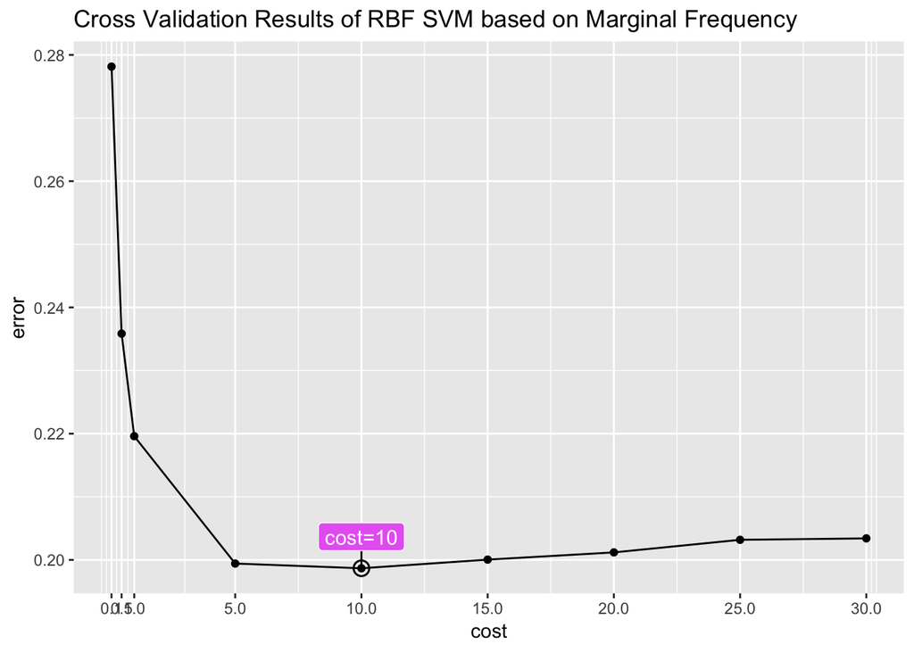

```r
tune.best.svm = svm[order(svm$error, decreasing = F)[1],]
## Tuning plot for RBF SVM
ggplot(svm, aes(cost, error)) + geom_point() + geom_line() +
  geom_point(data = tune.best.svm, col="black", size=3.5, stroke = 0.8, shape=21) +
  scale_x_continuous(breaks = c(.1,.5,1,5,10,15,20,25,30)) +
  geom_label_repel(data = tune.best.svm, label = "cost=10", color = 'white',
                   fill = hue_pal()(5)[5], segment.color="black", nudge_y = 0.005, size = 4) +
  ggtitle("Cross Validation Results of RBF SVM based on Marginal Frequency")
```

Given the results from cross-validation, we chose the value for `cost` that could minimize the cross-validation error. The optimal tuning parameters obtained from cross-validations were `cost`= 10 and $\gamma = 2^{-8}$, we then trained the RBF SVM with these tuning parameter values and made prediction.

```r
## Train RBF SVM classifier using the optimal tuning parameter (C=10, sigma2 = 2^8)
#model.svm <- svm(x = train_mar, y = factor(train.sample$toxic), cost = 10, gamma = 2^(-8))
label.predict <- predict(model.svm, test_mar)
# prediction accuracy
sum(label.predict==test_labels_use$toxic)/length(label.predict)
```

```
## [1] 0.7739067
```

```r
# confusion matrix
pred_MFSVM <- ifelse(label.predict==0,"pred_non_toxic","pred_toxic")
table_MFSVM <- table(pred_MFSVM, test_toxic)
print(table_MFSVM)
```

```
##                 test_toxic
## pred_MFSVM       expect_non_toxic expect_toxic
##   pred_non_toxic            44159          736
##   pred_toxic                13729         5354
```

```r
# marginal perventage
prop_table_MFSVM <- prop.table(table_MFSVM, 2)
print(prop_table_MFSVM)
```

```
##                 test_toxic
## pred_MFSVM       expect_non_toxic expect_toxic
##   pred_non_toxic        0.7628351    0.1208539
##   pred_toxic            0.2371649    0.8791461
```

The low sensitivity of LASSO classifier may also imply that the true dicision boundary might not be linear. So now we move forward and look at the performance of the classifier obtained through RBF SVM (using `svm` function from package `e1071`). Set $\sigma^2$ equal to $2^8$, by looking at the tuning plot we can see that the optimal cost $C=10$. When $C=10$ and $\sigma^2=2^8$, the classifier will have an overall accuracy of 77.4% with sensitivity equal to 87.9% and specifity equal to 76.3%. The RBF SVM classifier has a much higher senesitivity than all other classifiers we obtained before, however, its specifity is much lower than the senesitivity and classifier are more likely to identify nontoxic comments as toxic comments. Hence, it seems that the good performance of RBF SVM classifier for toxic comment is very likely due to overfitting.

### 4.3.3 Marginal Frequency –> Random Forest

To train Random Forest, we apply the function `train` in the R package `caret` and performed a grid search over possible values for tuning parameter `mtry`.

```r
rfGrid <- expand.grid(mtry=c(2, 4, 8, 12, 16, 20, 24, 28, 32, 36))

trCtl <- trainControl(method="cv", number=10, savePredictions=FALSE)
fit <- train(train_mar, as.factor(train_mar_y), method="rf", trControl=trCtl, tuneGrid = rfGrid)
```

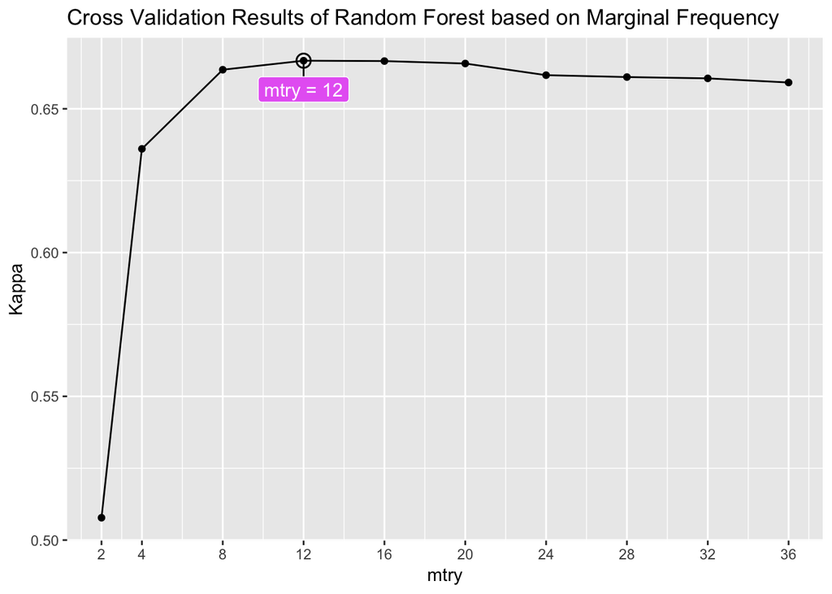

```r
rf_marfreq = result$results
tune.best = rf_marfreq[order(rf_marfreq$Kappa, decreasing = T)[1],]

# Kappa plot
ggplot(rf_marfreq, aes(mtry, Kappa)) + geom_point() + geom_line() +
  geom_point(data = tune.best, col="black", size=3.5, stroke = 0.8, shape=21) +
  scale_x_continuous(breaks = c(2,4,8,12,16,20,24,28,32,36)) +
  geom_label_repel(data = tune.best, label = "mtry = 12", color = 'white',
                   fill = hue_pal()(5)[5], segment.color="black", nudge_y = -0.01, size = 4) +
  ggtitle("Cross Validation Results of Random Forest based on Marginal Frequency")
```

Given the results from cross-validation, we chose the value for `mtry` that could maximize the Kappa or accuracy. The optimal tuning parameters obtained from cross-validation was `mtry`= 12 , we then trained the Random Forest with this tuning parameter value and made prediction.

```r
## model.rf <- randomForest(x = as.matrix(train_mar), y = factor(train.sample$toxic), mtry = 12)
label.predict <- predict(model.rf, test_mar)
# prediction accuracy
sum(label.predict==test_labels_use$toxic)/length(label.predict)
```

```
## [1] 0.8006033
```

```r
# confusion matrix
pred_MFRF <- ifelse(label.predict==0,"pred_non_toxic","pred_toxic")
table_MFRF <- table(pred_MFRF, test_toxic)
print(table_MFRF)
```

```
##                 test_toxic
## pred_MFRF        expect_non_toxic expect_toxic
##   pred_non_toxic            46081          950
##   pred_toxic                11807         5140
```

```r
# marginal perventage
prop_table_MFRF <- prop.table(table_MFRF, 2)
print(prop_table_MFRF)
```

```
##                 test_toxic
## pred_MFRF        expect_non_toxic expect_toxic
##   pred_non_toxic        0.7960372    0.1559934
##   pred_toxic            0.2039628    0.8440066
```

At last, we will try to look at the performance of the classifier obtained from Random Forest (use `randomForest` function from package `randomForest`). Set ntree to be default value 500, again, by looking at the tuning plot we can see that the optimal value for tuning parameter `mtry` is reached at `mtry`=12. The Random Forest classifier has an overall 80% accuracy, with the sensitivity of 84.4% and the specificity of 79.6%. Even though the overall accuracy of Random Forest classifier is lower than LASSO classifier and the sensitivity is lower than RBF SVM classifier, the Random Forest classifier is the only classifier with both a relatively high sensitivity and a relatively high specificity, which makes it more favorable to the LASSO classifier and SVM classifier.

## 4.4 Keyword Check

### 4.4.1 Data and Model

Define $y_i = I(a \; word \; in \; the \; vocabulary \; appears \; in \; the \; i_{th} \; comment)$, $\gamma_i = length \; of \; the \; i_{th} \; comment$, $z_i = I(the \; i_{th} \; comment \; is \; toxic)$. Then given the comment data (after tokenization and basic preprocessing) only, $y_i$ and $\gamma_i$ are observed for each subject $i$ while $z_i$’s are unobserved. For each group $k=0,1$ (1 indicating that the comment is toxic), model the occurrence of a word within a comment from one of the groups by a logistic regression model with an offset
$$logit({p_k}(y_i = 1|\gamma_i)) = \theta_k + \gamma_i,$$
let $\pi_k$ be the prior probability that the comment should fall into group $k$ (proportion of group $k$).

#### 4.4.1.1 (Observed Data) Log Likelihood

$$l(\boldsymbol{\theta}) = \sum_{i=1}^n \log\left( \sum_{k =0}^1 \pi_kp_k(y_i|\gamma_{i}, {\theta}_k)\right),$$
where $p_k(y_i|\gamma_{i}, {\theta}_k) = {p_k}(y_i = 1|\gamma_i)^{y_i} {p_k}(y_i = 0|\gamma_i)^{1-y_i}$, $logit({p_k}(y_i = 1|\gamma_i)) = \theta_k + \gamma_i$ and $\sum_{k = 0}^1 \pi_k = 1$.

#### 4.4.1.2 Complete Data Log Likelihood

$$\begin{align}
l_c(\boldsymbol{\theta}) &= \sum_{i=1}^n \log( \prod_{k =0}^1 \left[\pi_kp_k(y_i|\gamma_i, {\theta}_k)\right]^{I[z_i = k]}) \\
&= \sum_{i=1}^n \sum_{k =0}^1 I[z_i = k]\left[\log(\pi_k)+\log(p_k(y_i|\gamma_i, {\theta}_k))\right]\\
\end{align}$$

### 4.4.2 EM Algorithm

#### 4.4.2.1 E-step

Need to evaluate $Q(\boldsymbol{\theta}|\boldsymbol{\theta}^{(t)}) = E\left[ \log l_c(\boldsymbol{\theta}) | \boldsymbol{y}_o,\boldsymbol{\theta}^{(t)}\right]$, which can be simplified as the following:

$$\begin{align}
Q(\boldsymbol{\theta}|\boldsymbol{\theta}^{(t)}) &=\sum_{i=1}^n \sum_{k =0}^1 E[I[z_i = k] | \boldsymbol{y}_o, \boldsymbol{\theta}^{(t)}]\left[\log(\pi_k)+\log(p_k(y_i|\gamma_i, {\theta}_k))\right]\\
&= \sum_{i=1}^n \sum_{k =0}^1 p(z_i = k | \boldsymbol{y}_o, \boldsymbol{\theta}^{(t)})\left[\log(\pi_k)+\log(p_k(y_i|\gamma_i, {\theta}_k))\right]
\end{align}$$

where

$$\begin{align}
p(z_i = k | \boldsymbol{y}_o, \boldsymbol{\theta}^{(t)})
&= \frac{\pi_k^{(t)}p_k(y_i|\gamma_i, {\theta}^{(t)}_k)}{ \sum_{k =0}^1\pi_k^{(t)}p_k(y_i|\gamma_i, {\theta}^{(t)}_k)}
\end{align}$$

#### 4.4.2.2 M-step

The Q function can be separated as weighted log-likelihoods with prior weights being the posterior probabilities of group membership given the current updated value of parameters. The $\theta$’s can be updated by weighted logistic regression with an offset while the $\pi$’s can be updated simply by taking the average of posterior probabilities for being in each group.

#### 4.4.2.3 Implememtation

We summarized the above algorithm for fitting finite mixture logistic regression model into a function `mixlogistic` in our package `UmbrellaAcademy`. Our function can take in a data vector of keyword occurrence, a data vector of comment length, and another data vector of toxicity label and make prediction based on keyword occurrence for each subject using the posterior probabilities $p(z_i = 1 | \boldsymbol{y}_o, \boldsymbol{\theta}^{(t)})$ (posterior probability of belonging to “toxic” class given keyword occurrence and comment length). The prediction results were summarized as overall accuracy, sensitivity and specificity.

For illustration, we selected the first 30 keywords from each of the two datasets after dimension reduction (LASSO or marginal frequency selection). Then we applied function `mixlogistic` and obtained prediction results. In the result below, `accuracy_mf` stored the 30 overall prediction accuracies from each of the fisrt 30 keywords in the DTM obtained from marginal frequency selection, `sens_mf` stored the 30 sensitivities from each of the fisrt 30 keywords in the DTM obtained from marginal frequency selection, `accuracy_lasso` stored the 30 overall prediction accuracies from each of the fisrt 30 keywords in the DTM obtained from LASSO selection, and `sens_lasso` stored the 30 sensitivities from each of the fisrt 30 keywords in the DTM obtained from LASSO selection. These results were shown below in summaries.

```r
train_mar <- cbind(train_mar_id[,2], train_mar)
train_mar <- train_mar[order(train_mar[,1]),]
train_mar <- train_mar[,-1]
train_mar <- apply(train_mar,2,as.numeric)
train_mar[which(train_mar > 0)] <- 1 ##30588 by 277 matrix

train_sub <- train.data[which(unlist(train.data$id) %in% train_mar_id[,2]),]
train_sub <- train_sub[order(train_sub$id),]

label <- train_sub$toxic
l <- sapply(train_sub$comment_text, strsplit, " ")
gamma <- unlist(lapply(l,length)) ##30588 length vector
gamma <- unname(gamma)
#gamma <- rep(0,nrow(train_mar))

y <- train_mar[,2]
n <- nrow(train_mar)

train_mar_new <- train_mar[,-which(colSums(train_mar) == 0)]
kw_mf <- kw[-which(colSums(train_mar) == 0),2]
colnames(train_mar_new) <- kw_mf

res_mf <- apply(train_mar_new[,1:30], 2, mixlogistic, gamma=gamma, tol=10^-5, maxit=50, prop_toxic=0.5, label=label)
accuracy_mf <- unlist(lapply(res_mf, '[[', 4))
sens_mf <- unlist(lapply(res_mf, '[[', 5))
spec_mf <- unlist(lapply(res_mf, '[[', 6))
summary(accuracy_mf)
```

```
##    Min. 1st Qu.  Median    Mean 3rd Qu.    Max.
##  0.4149  0.4897  0.4936  0.4915  0.5004  0.5981
```

```r
summary(sens_mf)
```

```
##    Min. 1st Qu.  Median    Mean 3rd Qu.    Max.
##  0.5813  0.9518  0.9689  0.9400  0.9927  0.9999
```

```r
dense.train.dtm[which(dense.train.dtm > 0)] <- 1
res_lasso <- apply(dense.train.dtm[,1:30], 2, mixlogistic, gamma=gamma, label=label, Trace = F)
accuracy_lasso <- unlist(lapply(res_lasso, '[[', 4))
sens_lasso <- unlist(lapply(res_lasso, '[[', 5))
spec_lasso <- unlist(lapply(res_lasso, '[[', 6))
summary(accuracy_lasso)
```

```
##    Min. 1st Qu.  Median    Mean 3rd Qu.    Max.
##  0.4997  0.4999  0.5000  0.5000  0.5002  0.5006
```

```r
summary(sens_lasso)
```

```
##    Min. 1st Qu.  Median    Mean 3rd Qu.    Max.
##  0.9954  0.9966  0.9975  0.9973  0.9983  0.9990
```

# 5 Discussion

## 5.1 Strengths:

- Our method is easy to implement and the results are interpretable. It’s feasible to apply our method to other datasets of toxic comments and to classify other types of comments such as favorable/negative review.
- The prediction results (especially based on Marginal Frequency) are satisfactory. We also train an **xgboost** model using LSA and TF-IDF to preprocess raw data (we borrowed codes from kaggle), which gives the overall accuracy of about 85%. It’s very close to the accuracy achieved from Marginal Frequency and LASSO.

## 5.2 Limitation:

- The selection of tuning parameters for both Random Forest and SVM is computationally intensive (mainly due to the use of package `caret` when training Random Forest and SVM).
- We down-sample our training set to create a balanced dataset to build and train our models, which may cause the loss of information of the nontoxic group.
- We predict the results based on a much larger and unbalanced test dataset (size of 63k records, ratio of toxic to nontoxic comments = 1:9), comparing with the training set of 30k records. The difference in size of datasets and ratio of toxic and nontoxic comments may lead to inaccuracy in both toxic and nontoxic predictions.

## 5.3 Moving Forward:

- Some comments cannot be classified correctly due to the way we tokenize and vectorize comments. We can improve this by looking at specific patterns of comments.

# 6 References

[1] Word frequency data https://www.wordfrequency.info/free.asp?s=y